# Sparkify Project

This project has the purpose of predicting the churn rate of Sparkify's service. In particular, it's significant to understand if a user will leave the service. The dataset contains the action logs of each user, and it exists in two versions. The first is the full dataset of 12GB present only on AWS. The other is smaller, and it has a size of 232MB. The mandatory requirement of this project is the use of SPARK.

```python
sc.list_packages() #Check installed packages
```

```
Starting Spark application
```

| ID | YARN Application ID | Kind | State | Spark UI | Driver log | Current session? |
| --- | --- | --- | --- | --- | --- | --- |
| 14 | application_1598337564684_0015 | pyspark | idle | [Link](http://ip-172-31-43-131.eu-central-1.compute.internal:20888/proxy/application_1598337564684_0015/) | [Link](http://ip-172-31-33-216.eu-central-1.compute.internal:8042/node/containerlogs/container_1598337564684_0015_01_000001/livy) | ✔ |

```
SparkSession available as 'spark'.
```

```
Package                    Version
-------------------------- -------
beautifulsoup4             4.9.0
boto                       2.49.0
jmespath                   0.9.5
lxml                       4.5.0
mysqlclient                1.4.2
nltk                       3.4.5
nose                       1.3.4
numpy                      1.16.5
pip                        9.0.1
py-dateutil                2.2
python37-sagemaker-pyspark 1.3.0
pytz                       2019.3
PyYAML                     5.3.1
setuptools                 28.8.0
six                        1.13.0
soupsieve                  1.9.5
wheel                      0.29.0
windmill                   1.6
```

```python
sc.getConf().get('spark.driver.memory') #Check memory allocated from driver
```

```
'6G'
```

```python
#Install the dependecies. Remember to install them at each restart of kernel
sc.install_pypi_package('matplotlib')
sc.install_pypi_package('seaborn')
sc.install_pypi_package('handyspark')
sc.install_pypi_package('user_agents')
sc.install_pypi_package('pyspark2pmml')
```

[output not shown]

```python
from pyspark.sql import SparkSession, Window
import matplotlib.pyplot as plt
import seaborn as sb
import handyspark
from pyspark.mllib.stat import Statistics
from pyspark.ml.feature import  VectorAssembler
from pyspark.ml import Pipeline
from pyspark.sql.types import StringType, FloatType
from pyspark.sql.functions import udf
from pyspark.ml.classification import LogisticRegression, NaiveBayes, RandomForestClassifier
from pyspark.ml.tuning import ParamGridBuilder, CrossValidator
from pyspark.ml.regression import GeneralizedLinearRegression
from pyspark.ml.evaluation import BinaryClassificationEvaluator, MulticlassClassificationEvaluator
import pyspark.sql.functions as func
import numpy as np
from pyspark2pmml import PMMLBuilder
from user_agents import parse
```

```python
#Launch spark session
#Please remember to download JAR at https://github.com/jpmml/pyspark2pmml#configuration-and-usage and
#upload in the master node in /home/hadoops/extrajars/

lib = 'jpmml-sparkml-executable-1.5.8.jar' #This java library is mandatory to export the model in PMML format

spark = SparkSession.builder. \
    config('spark.jars',lib).appName("Sparkify detect Cancellation").getOrCreate()
```

## Data understanding

```python
event ='s3n://udacity-dsnd/sparkify/sparkify_event_data.json'
#event ='s3n://udacity-dsnd/sparkify/mini_sparkify_event_data.json' # A small dataset to use only for test
df = spark.read.json(event) #read the data
```

```python
df.dtypes #show the data types of each column
```

```
[('artist', 'string'), ('auth', 'string'), ('firstName', 'string'), ('gender', 'string'), ('itemInSession', 'bigint'), ('lastName', 'string'), ('length', 'double'), ('level', 'string'), ('location', 'string'), ('method', 'string'), ('page', 'string'), ('registration', 'bigint'), ('sessionId', 'bigin…
```

```python
handyDf = df.toHandy() #Convert to Handy DataFrame
```

```python
df.head()
```

```
Row(artist='Popol Vuh', auth='Logged In', firstName='Shlok', gender='M', itemInSession=278, lastName='Johnson', length=524.32934, level='paid', location='Dallas-Fort Worth-Arlington, TX', method='PUT', page='NextSong', registration=1533734541000, sessionId=22683, song='Ich mache einen Spiegel - Drea…
```

```python
df.describe().toPandas()
```

```
  summary  ...              userId
0   count  ...            26259199
1    mean  ...  1488379.8347142653
2  stddev  ...  286970.08894623973
3     min  ...             1000025
4     max  ...             1999996

[5 rows x 19 columns]
```

```python
handyDf.isnull() #Find NA values
```

```
artist           5408927
auth                   0
firstName         778479
gender            778479
itemInSession          0
lastName          778479
length           5408927
level                  0
location          778479
method                 0
page                   0
registration      778479
sessionId              0
song             5408927
status                 0
ts                     0
userAgent         778479
userId                 0
Name: missing, dtype: int64
```

The columns firstName, gender, lastName, registration, and userAgent have the same of NA values. It leads us to conjecture that NAs are in the same rows.

```python
handyDf.dropna(subset=['registration']).isnull()
```

```
artist           4630448
auth                   0
firstName              0
gender                 0
itemInSession          0
lastName               0
length           4630448
level                  0
location               0
method                 0
page                   0
registration           0
sessionId              0
song             4630448
status                 0
ts                     0
userAgent              0
userId                 0
Name: missing, dtype: int64
```

Dropping rows with the NA values in the registration column, we observe there aren't NAs in the other related columns

```python
df.select('userId').dropDuplicates().count() #number of users
```

```
22278
```

```python
df.select('level').dropDuplicates().collect() #the levels
```

```
[Row(level='free'), Row(level='paid')]
```

```python
df.select('status').dropDuplicates().collect() #HTTP code response
```

```
[Row(status=200), Row(status=404), Row(status=307)]
```

```python
df.select('page').dropDuplicates().collect() #The page that user can navigate
```

[output not shown]

```python
df.select('userAgent').dropDuplicates().count() #The number of user agent
```

```
86
```

```python
df.select('userId').filter(df.page == 'Cancellation Confirmation').dropDuplicates().count() #Number of churn user
```

```
5003
```

Now we investigate what user does before leaving the service. In particular we observe the actions in the last year.

```python
df.createOrReplaceTempView('events')
```

```python
action_churn_users_last_year = spark.sql('SELECT *, \
          (SELECT (from_unixtime(max(e2.ts) DIV 1000)) FROM events as e2 \
          WHERE e2.userId = e.userId AND page = \'Cancellation Confirmation\') as churn, \
          from_unixtime(e.ts DIV 1000) as ev_date, \
          from_unixtime(e.registration DIV 1000) as reg_date \
          FROM events as e \
          WHERE from_unixtime(ts DIV 1000) > \
          (SELECT date_sub(from_unixtime(max(e2.ts) DIV 1000), 365) FROM events as e2 \
          WHERE e2.userId = e.userId AND page = \'Cancellation Confirmation\')')
```

```python
action_churn_users_last_year.select('userId').dropDuplicates().count() #The number of churn users
```

```
5003
```

```python
#Additional check: We make sure that the user doesn't any actions since left the service
spark.sql('SELECT count(*) as num \
          FROM events as e \
          WHERE ts > \
          (SELECT max(e2.ts) FROM events as e2 \
          WHERE e2.userId = e.userId AND page = \'Cancellation Confirmation\'\
          ) ').head()
```

```
Row(num=0)
```

```python
action_churn_users_last_year.select(['userId','churn','reg_date']).dropDuplicates().show()
```

```
+-------+-------------------+-------------------+
| userId|              churn|           reg_date|
+-------+-------------------+-------------------+
|1883991|2018-11-08 18:05:22|2018-09-30 20:09:20|
|1675930|2018-10-22 02:52:40|2018-09-03 15:00:43|
|1720899|2018-10-12 08:13:57|2018-09-08 21:07:09|
|1008404|2018-11-09 11:04:20|2018-07-21 03:14:00|
|1627452|2018-10-22 06:44:18|2018-08-26 21:53:22|
|1205653|2018-11-11 03:30:41|2018-08-10 00:53:01|
|1524082|2018-10-17 10:22:01|2018-08-20 10:04:06|
|1931889|2018-11-23 03:25:50|2018-09-08 18:44:27|
|1241210|2018-10-15 06:04:56|2018-09-04 20:56:19|
|1904924|2018-11-18 09:22:20|2018-09-21 16:01:30|
|1721727|2018-11-28 15:12:09|2018-06-22 10:54:26|
|1637236|2018-11-23 19:28:56|2018-08-11 15:32:04|
|1577579|2018-11-13 16:57:54|2018-08-19 00:23:34|
|1951516|2018-11-14 21:39:07|2018-08-07 19:04:48|
|1807588|2018-11-27 14:09:37|2018-07-18 16:22:28|
|1534570|2018-10-10 20:38:59|2018-09-26 09:12:10|
|1977419|2018-10-15 17:32:22|2018-09-23 18:18:17|
|1814892|2018-10-23 23:00:20|2018-06-19 15:03:03|
|1182149|2018-11-29 23:03:20|2018-09-19 02:47:49|
|1403675|2018-10-09 15:52:41|2018-09-23 10:06:50|
+-------+-------------------+-------------------+
only showing top 20 rows
```

We aggregate the data to understand how many days there are between registration and the cancellation.

```python
action_churn_users_last_year.createOrReplaceTempView('before_churn_events')
```

```python
tmp = spark.sql('SELECT ROUND(datediff(churn, reg_date)) as n_days, \
          userId \
          FROM before_churn_events as e \
          GROUP BY userId,n_days \
          ').toPandas()
```

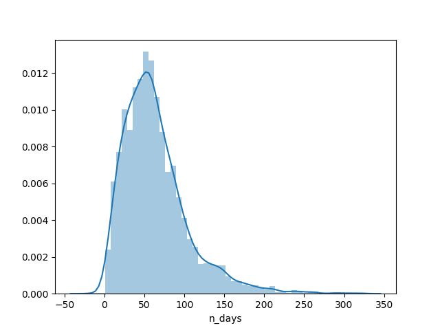

```python
sb.distplot(tmp.n_days) #Distribution plot
%matplot plt
```

```python
tmp.n_days.mean(), tmp.n_days.std()
```

```
(63.680391764941035, 41.281365394508136)
```

We can observe that most cancellations occur in the first 250 days from registration.

## Prepare data

```python
spark.catalog.clearCache()
df.dropna(subset=['registration']).createOrReplaceTempView('events') #Drop NA values of registration
```

```python
#Create a dataframe that contains user actions since the 150 days from registration date
user_first_250days = spark.sql("""
        SELECT *,
          from_unixtime(e.ts DIV 1000) as ev_date,
          from_unixtime(e.registration DIV 1000) as reg_date,
          (CASE WHEN datediff(from_unixtime(e.ts DIV 1000),from_unixtime(e.registration DIV 1000)) > 0 THEN datediff(from_unixtime(e.ts DIV 1000),from_unixtime(e.registration DIV 1000)) ELSE 0 END)
           as n_days,
          (SELECT COUNT(*) from events as e2 where e2.userId = e.userId AND e2.page = \'Cancellation Confirmation\') as is_churn
          FROM events as e
          WHERE from_unixtime(ts DIV 1000) <
          (SELECT date_add(from_unixtime(max(e2.registration) DIV 1000), 150) FROM events as e2
          WHERE e2.userId = e.userId)
          """)
```

```python
#Map Useragent to a family browser
udf_ua = udf(lambda x: parse(x).browser.family, StringType())
```

```python
user_first_250days.cache()
pivot_page = user_first_250days.where('page <> \'Cancellation Confirmation\'').groupBy(['userId','is_churn','n_days']).pivot('page').count()
pivot_level = user_first_250days.groupBy(['userId','is_churn','n_days']).pivot('level').count()
pivot_gender = user_first_250days.groupBy(['userId','is_churn','n_days']).pivot('gender').count()
pivot_method = user_first_250days.groupBy(['userId','is_churn','n_days']).pivot('method').count()
pivot_status = user_first_250days.groupBy(['userId','is_churn','n_days']).pivot('status').count()
pivot_user_agent = user_first_250days.withColumn('userAgentUA',udf_ua('userAgent')).groupBy(['userId','is_churn','n_days']).pivot('userAgentUA').count()
pivot_auth = user_first_250days.groupBy(['userId','is_churn','n_days']).pivot('auth').count()
```

```python
pivot = pivot_page.join(pivot_level,on=['userId','is_churn','n_days'],how='inner'). \
  join(pivot_method,on=['userId','is_churn','n_days'],how='inner'). \
  join(pivot_status,on=['userId','is_churn','n_days'],how='inner'). \
  join(pivot_gender,on=['userId','is_churn','n_days'],how='inner'). \
  join(pivot_user_agent,on=['userId','is_churn','n_days'],how='inner'). \
  join(pivot_auth,on=['userId','is_churn','n_days'],how='inner').fillna(0)
```

```python
pivot.limit(5).toPandas()
```

```
    userId  is_churn  n_days  ...  Safari  Cancelled  Logged In
0  1000035         0      36  ...       0          0         18
1  1000164         0      63  ...       0          0          5
2  1000164         0      68  ...       0          0         69
3  1000164         0     110  ...       0          0         38
4  1000280         1      34  ...       0          0         37

[5 rows x 39 columns]
```

Each row aggregates the interactions done by the user for each day since the registration date. It's present the boolean column is_churn that describes if the user will leave the service.

## Data modeling (analyze and model)

The model should predict for each day if the user is a "churn user" or not. We aspect that the majority of actions haven't significant differences between "churn user" and active user. It probably influences predictions by increasing false positives or false negatives. To better define this circumstance, we create two models, one based on the Naive Bayes Classifier, and the other based on Logic Regression.

```python
cols = pivot.columns
cols.remove('is_churn')
cols.remove('userId')
assembler = VectorAssembler(inputCols=cols, outputCol="features")
bayes =  NaiveBayes(modelType="multinomial")
lr = LogisticRegression()
bayes_stages = [assembler, bayes]
lr_stages = [assembler, lr]
pivot = pivot.withColumnRenamed("is_churn","label")
```

The random split of the dataset is based on userId to prevent that user data is partial inside the train or test dataset.

```python
trainUserIds, testUserIds = pivot.select('userId').dropDuplicates().randomSplit([0.7, 0.3], seed = 1234)
```

```python
train = pivot.filter(pivot.userId.isin(trainUserIds.userId))
test = pivot.filter(pivot.userId.isin(testUserIds.userId))
```

```python
spark.catalog.clearCache()
train.cache()
test.cache()

bayes_pipeline = Pipeline(stages = bayes_stages)
lr_pipeline = Pipeline(stages = lr_stages)

bayes_paramGrid = ParamGridBuilder()\
    .addGrid(bayes.smoothing, [0.25, 1.0])\
    .build()
lr_paramGrid = ParamGridBuilder()\
    .addGrid(lr.maxIter,[100, 500])\
    .build()

bayes_crossval = CrossValidator(estimator=bayes_pipeline,
                          estimatorParamMaps=bayes_paramGrid,
                          evaluator=BinaryClassificationEvaluator())

lr_crossval = CrossValidator(estimator=lr_pipeline,
                          estimatorParamMaps=lr_paramGrid,
                          evaluator=BinaryClassificationEvaluator())
```

```python
bayes_cvModel = bayes_crossval.fit(train)
bayes_predictions = bayes_cvModel.transform(test)
```

```python
lr_cvModel = lr_crossval.fit(train)
lr_predictions = lr_cvModel.transform(test)
```

## Evaluate the Results

We start to evaluate the two models using a standard way. We compare the F1 Score, Accuracy Score, Weighted Recall, and the ratio of predicted churn users over the number of churn users.

```python
def print_model_evaluation(predictions):
    """
    This function prints F1 score, Accuracy score, weighted recall score,
    and the ratio of predicted churn users over the number of churn users.
    params:
        predictions - (Dataframe) the predicted values

    """
    evaluator =  MulticlassClassificationEvaluator()
    #Print F1 Score, Accuracy and weighted recall
    print('F1 Score = ' + str(evaluator.evaluate(predictions, {evaluator.metricName: "f1"})))
    print('Accuracy Score = ' + str(evaluator.evaluate(predictions, {evaluator.metricName: "accuracy"})))
    print('Weighted Recall = ' + str(evaluator.evaluate(predictions, {evaluator.metricName: "weightedRecall"})))

    #print the ratio of cancelled account predicted
    correct_1 = (predictions.where('label = 1').where(predictions.where('label = 1').prediction == predictions.where('label = 1').label).select('userId').dropDuplicates().count())
    total_1 = predictions.where('label = 1').select('userId').dropDuplicates().count()
    print("Total churn users: " + str(total_1))
    print("Number predicted churn users: " + str(correct_1))
    print("Ratio: " + str(correct_1/total_1))
```

```python
print("Naive Bayes: "), print_model_evaluation(bayes_predictions)
```

```
Naive Bayes:
F1 Score = 0.6763166451101013
Accuracy Score = 0.644754635759245
Weighted Recall = 0.644754635759245
Total churn users: 4901
Number predicted churn users: 4553
Ratio: 0.9289940828402367
(None, None)
```

```python
print("Logistic Regression: "), print_model_evaluation(lr_predictions)
```

```
Logistic Regression:
F1 Score = 0.7604781055264619
Accuracy Score = 0.8235508605979934
Weighted Recall = 0.8235508605979934
Total churn users: 4901
Number predicted churn users: 4793
Ratio: 0.9779636808814528
(None, None)
```

We observe that the logistic regression model has better result respect the Naive Bayes model. With these models, we can predict for each day if the user will leave the service. Before the user cancellation, we can predict it. If every day we have the aggregate data for the activity of the user like the dataset, we can apply the model and understand the his intention. We can arbitrarily define that with only one predicted value equals to 1, we consider him as a potential churn user. If we use only the first value, the probability of a false positive can be high. We can reduce it by considering more predictions instead of only one.

```python
def print_strategy(predictions, n=1):
    """
    This functions prints  two indicators:
    * the ratio of predicted churn users considering the 50%, 70%, 80%, 90%, 99% of days of the duration of account.
    * the ratio of false positive considering the 50%, 70%, 80%, 90%, 99% of days of the duration of account.

    params:
        predictions - (Dataframe) the predicitons
        n - the number of true values before consider the user as "churn user"
    """
    aggregated_predictions = predictions.groupBy('userId','prediction','label').agg(func.count('*').alias("Num Of Records")).select('userId','prediction','label')
    predictions.createOrReplaceTempView("predictions")
    total = predictions.where('label = 1').select('userId').dropDuplicates().count()
    for perc in [0.5, 0.7, 0.8, 0.9, 0.99]:
        res = spark.sql("""
        SELECT userId,MAX(n_days)*{} AS days,SUM(prediction) as num_predicted
        FROM predictions as p
        WHERE label = 1 AND n_days <= (SELECT MAX(n_days)*{} FROM predictions as p2 where p2.userId = p.userId)
        GROUP BY userId
        HAVING num_predicted >= {}
        """.format(perc, perc,n))
        print("Counting at least "+ str(n) + " positive values at " + str(perc*100) + "% of live of account, it predicts the "+ str(res.count()/total))
    total = predictions.where('label = 0').select('userId').dropDuplicates().count()
    for perc in [0.5 , 0.7, 0.8, 0.9, 0.99]:
        res = spark.sql("""
        SELECT userId,MAX(n_days)*{} AS days,SUM(prediction) as num_predicted
        FROM predictions as p
        WHERE label = 0 AND n_days <= (SELECT MAX(n_days)*{} FROM predictions as p2 where p2.userId = p.userId)
        GROUP BY userId
        HAVING num_predicted >= {}
        """.format(perc, perc, n))
        print("Counting at least "+ str(n) + " positive values at " + str(perc*100) + "% of live of account, it predicts false positive "+ str(res.count()/total))
```

```python
print("Naive Bayes: "), print_strategy(bayes_predictions, 1)
print("Naive Bayes: "), print_strategy(bayes_predictions, 2)
print("Naive Bayes: "), print_strategy(bayes_predictions, 3)
```

```
Naive Bayes:
Counting at least 1 positive values at 50.0% of live of account, it predicts the 0.34931646602734134
Counting at least 1 positive values at 70.0% of live of account, it predicts the 0.5164252193429912
Counting at least 1 positive values at 80.0% of live of account, it predicts the 0.6000816159967354
Counting at least 1 positive values at 90.0% of live of account, it predicts the 0.6768006529279739
Counting at least 1 positive values at 99.0% of live of account, it predicts the 0.7500510099979596
Counting at least 1 positive values at 50.0% of live of account, it predicts false positive 0.48690511380431567
Counting at least 1 positive values at 70.0% of live of account, it predicts false positive 0.6310966597694354
Counting at least 1 positive values at 80.0% of live of account, it predicts false positive 0.6671002069169376
Counting at least 1 positive values at 90.0% of live of account, it predicts false positive 0.6937629323086019
Counting at least 1 positive values at 99.0% of live of account, it predicts false positive 0.7142181495713863
Naive Bayes:
Counting at least 2 positive values at 50.0% of live of account, it predicts the 0.2501530299938788
Counting at least 2 positive values at 70.0% of live of account, it predicts the 0.39359314425627423
Counting at least 2 positive values at 80.0% of live of account, it predicts the 0.46806774127729034
Counting at least 2 positive values at 90.0% of live of account, it predicts the 0.5339726586410937
Counting at least 2 positive values at 99.0% of live of account, it predicts the 0.5974290961028361
Counting at least 2 positive values at 50.0% of live of account, it predicts false positive 0.33490984333431867
Counting at least 2 positive values at 70.0% of live of account, it predicts false positive 0.46071534141294707
Counting at least 2 positive values at 80.0% of live of account, it predicts false positive 0.5003251551877033
Counting at least 2 positive values at 90.0% of live of account, it predicts false positive 0.5294117647058824
Counting at least 2 positive values at 99.0% of live of account, it predicts false positive 0.5538279633461425
Naive Bayes:
Counting at least 3 positive values at 50.0% of live of account, it predicts the 0.1834319526627219
Counting at least 3 positive values at 70.0% of live of account, it predicts the 0.3076923076923077
Counting at least 3 positive values at 80.0% of live of account, it predicts the 0.3717608651295654
Counting at least 3 positive values at 90.0% of live of account, it predicts the 0.4284839828606407
Counting at least 3 positive values at 99.0% of live of account, it predicts the 0.4894919404203224
Counting at least 3 positive values at 50.0% of live of account, it predicts false positive 0.23570795152231747
Counting at least 3 positive values at 70.0% of live of account, it predicts false positive 0.3452556902157848
Counting at least 3 positive values at 80.0% of live of account, it predicts false positive 0.38368312148980194
Counting at least 3 positive values at 90.0% of live of account, it predicts false positive 0.4150753768844221
Counting at least 3 positive values at 99.0% of live of account, it predicts false positive 0.4402601241501626
(None, None)
```

```python
print("Logistic Regression: "), print_strategy(lr_predictions, 1)
print("Logistic Regression: "), print_strategy(lr_predictions, 2)
print("Logistic Regression: "), print_strategy(lr_predictions, 3)
```

```
Logistic Regression:
Counting at least 1 positive values at 50.0% of live of account, it predicts the 0.029993878800244848
Counting at least 1 positive values at 70.0% of live of account, it predicts the 0.04998979800040808
Counting at least 1 positive values at 80.0% of live of account, it predicts the 0.0612119975515201
Counting at least 1 positive values at 90.0% of live of account, it predicts the 0.06937359722505611
Counting at least 1 positive values at 99.0% of live of account, it predicts the 0.08182003672719854
Counting at least 1 positive values at 50.0% of live of account, it predicts false positive 0.010050251256281407
Counting at least 1 positive values at 70.0% of live of account, it predicts false positive 0.013715637008572272
Counting at least 1 positive values at 80.0% of live of account, it predicts false positive 0.014898019509311262
Counting at least 1 positive values at 90.0% of live of account, it predicts false positive 0.015725687259828553
Counting at least 1 positive values at 99.0% of live of account, it predicts false positive 0.0164942358853089
Logistic Regression:
Counting at least 2 positive values at 50.0% of live of account, it predicts the 0.0071413997143440116
Counting at least 2 positive values at 70.0% of live of account, it predicts the 0.011426239542950418
Counting at least 2 positive values at 80.0% of live of account, it predicts the 0.013466639461334421
Counting at least 2 positive values at 90.0% of live of account, it predicts the 0.01693531932258723
Counting at least 2 positive values at 99.0% of live of account, it predicts the 0.01938379922464803
Counting at least 2 positive values at 50.0% of live of account, it predicts false positive 0.0010641442506650902
Counting at least 2 positive values at 70.0% of live of account, it predicts false positive 0.001418859000886787
Counting at least 2 positive values at 80.0% of live of account, it predicts false positive 0.0017735737511084836
Counting at least 2 positive values at 90.0% of live of account, it predicts false positive 0.0021874076263671298
Counting at least 2 positive values at 99.0% of live of account, it predicts false positive 0.002246526751404079
Logistic Regression:
Counting at least 3 positive values at 50.0% of live of account, it predicts the 0.0022444399102224035
Counting at least 3 positive values at 70.0% of live of account, it predicts the 0.003672719853091206
Counting at least 3 positive values at 80.0% of live of account, it predicts the 0.004488879820444807
Counting at least 3 positive values at 90.0% of live of account, it predicts the 0.005713119771475209
Counting at least 3 positive values at 99.0% of live of account, it predicts the 0.005713119771475209
Counting at least 3 positive values at 50.0% of live of account, it predicts false positive 0.0002364765001477978
Counting at least 3 positive values at 70.0% of live of account, it predicts false positive 0.0002955956251847473
Counting at least 3 positive values at 80.0% of live of account, it predicts false positive 0.0004729530002955956
Counting at least 3 positive values at 90.0% of live of account, it predicts false positive 0.0004729530002955956
Counting at least 3 positive values at 99.0% of live of account, it predicts false positive 0.0004729530002955956
(None, None)
```

```python
#Export model to PMML
pmmlBuilder = PMMLBuilder(spark, pivot, bayes_cvModel.bestModel).putOption(bayes, "compact", True)
pmmlBuilder.buildFile("/tmp/bayes.pmml") #The file is in the master node in /tmp/
```

```
'/tmp/bayes.pmml'
```

```python
#Export model to PMML
pmmlBuilder = PMMLBuilder(spark, pivot, lr_cvModel.bestModel).putOption(lr, "compact", True)
pmmlBuilder.buildFile("/tmp/lr.pmml") #The file is in the master node in /tmp/
```

```
'/tmp/lr.pmml'
```